# Day_5 slides

### Histogram plot

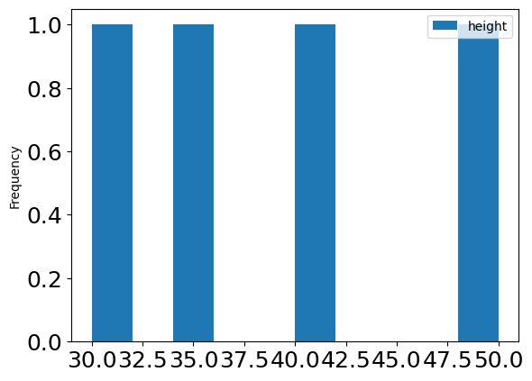

```python
df_small.plot(kind='hist', y = 'height', fontsize=18)
```

### Box plot

```
<pandas.plotting._core.PlotAccessor object at 0x315818b90>
```

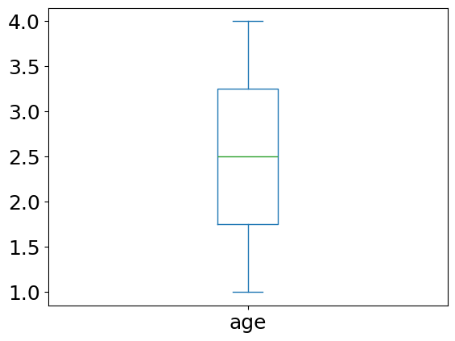

```python
df_small.plot(kind='box', y = 'age', fontsize=18)
df_small.plot
```

### Multiple graphs - grouping

```python
df.groupby('Tree')
```

```
<pandas.core.groupby.generic.DataFrameGroupBy object at 0x316ecdf50>
```

```
Tree
1    Axes(0.125,0.11;0.775x0.77)
2    Axes(0.125,0.11;0.775x0.77)
3    Axes(0.125,0.11;0.775x0.77)
dtype: object
```

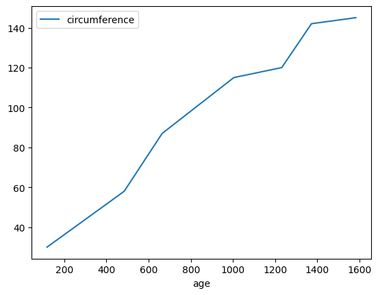

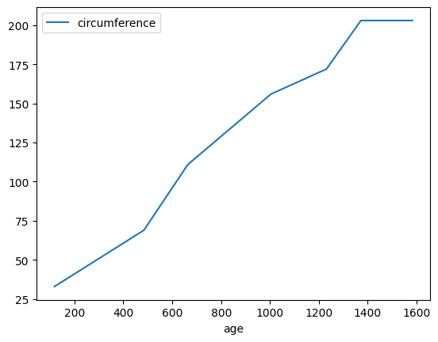

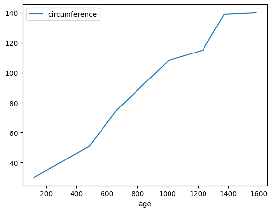

```python
df.groupby('Tree').plot(kind="line", x='age', y='circumference')
```

```python
tree3 = df.groupby('Tree').get_group(3)
```

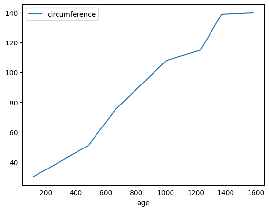

```python
tree3.plot(kind='line', x='age', y='circumference')
```

```python
df.groupby('Tree').groups
```

```
{1: [0, 1, 2, 3, 4, 5, 6], 2: [7, 8, 9, 10, 11, 12, 13], 3: [14, 15, 16, 17, 18, 19, 20]}
```

### Take a break

## Day 5, Exercise 1

- Link: https://python-bioinfo.bioshu.se/exercises.html

## Introduction to AI assisted programming

### (AI) Artificial Intelligence: A Global Phenomenon

[figure not shown]

## What AI can do

- Helping with decision-making, automation, and data analysis.
- Creating Art work
- Assisting in health care
- Self-driving car
- Serving as a good friend, mentor
- **Helping with programmming** (this is what we care in this course)

## AI can program when instructed with natural language

### Task:

Write a standalone Python script that calculate sequence length given a fasta file, it can take a fasta file as input from the command line and output the result

#### Input the above instruction to both Baidu Yiyan and ChatGPT.

## Rephrase the prompt run again

I have a sequence file in fasta format. The file may contain multiple sequences. Write a Python script that can take the sequence as an argument from the command line and print the result in the following format

seqid seqlength

## For more complicated tasks, AI may not generate the code that you can directly use

### Task:

I have sequenced the whole genome of a patient using Illumina. The raw data are in these fastq files. Write python script to assemble these into a whole genome and annotate it. also find all biomarkers that are related to type 2 diabetes.

### A practical procedure

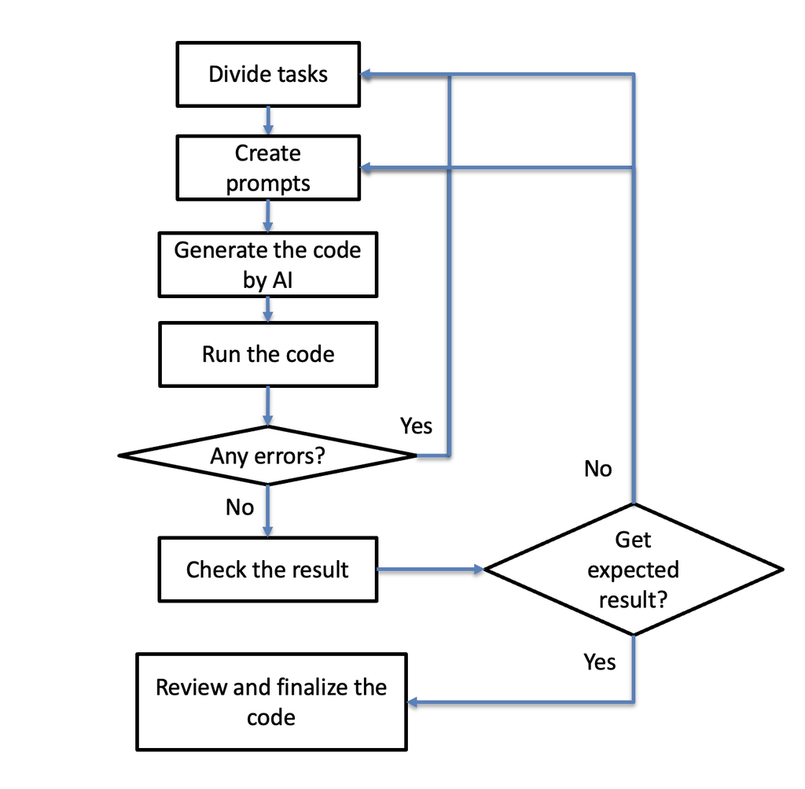

- There is actually a type of job: **prompt engineer** - designs and refines prompts for LLMs to accomplish the tasks

### AI can be integrated into the text editors, e.g.

- Github Copilot
  - developed by GitHub in collab with OpenAI
  - provides context-aware code suggestions
  - help writing code, debugging
- IntelliCode
  - by Microsoft
  - provides context-aware code suggestions
- Tabnine
  - code completion tool
- Kite
  - helps with code completion, error correction, and code navigation

It can generate or predict the code while you are programming

### Demo with Github Copilot using VScode

### Why do we still need to learn Python if AI can program?

- AI has limitations and can generate incorrect or suboptimal code
  - Understanding the fundamentals allows you to identify, troubleshoot, and fix these issues.
- Learning programming fundamentals helps develop problem-solving skills and algorithmic thinking
  - You need to guide AI with algorithmic thinking so that AI can generate expected result
- AI still lacks true innovation
  - It generates code based on existing patterns and data

### Pros

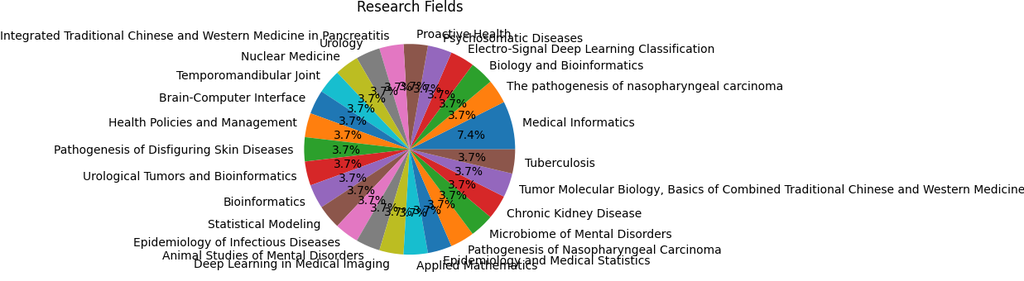

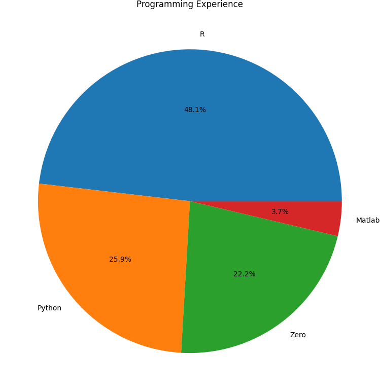

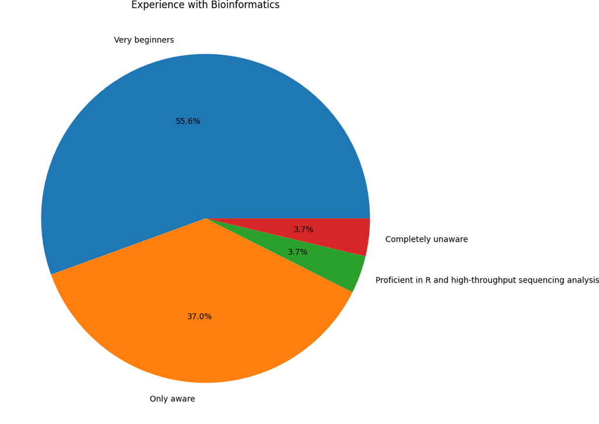

## Exercise (15 min)

Create the same figure using AI, given the Excel file python-bioinfo.bioshu.se/lectures/student_survey.xlsx

#### Take a short break before summary

## Summary

You have learned the fundermentals of Python and now you should be able to

- Know how to write a Python script to acheive basic bioinformatics tasks
- Know how to use the Python modules and packages to facilitate your coding task
- Know basics of data analysis and plotting with the Pandas module
- Know how to further develop your Python skills with numeras online tutorials and documentation

### Learning programming in the post-AI era

- With the emergency of AI tools, memorizing numerous modules and methods is less important than before (unless efficiency is key).
- The ability of decomposing tasks with algorithm thinking is more important.
- A broad domain knowledge is essential for effectively instructing and leveraging AI tools.

### The learning and forgetting curve

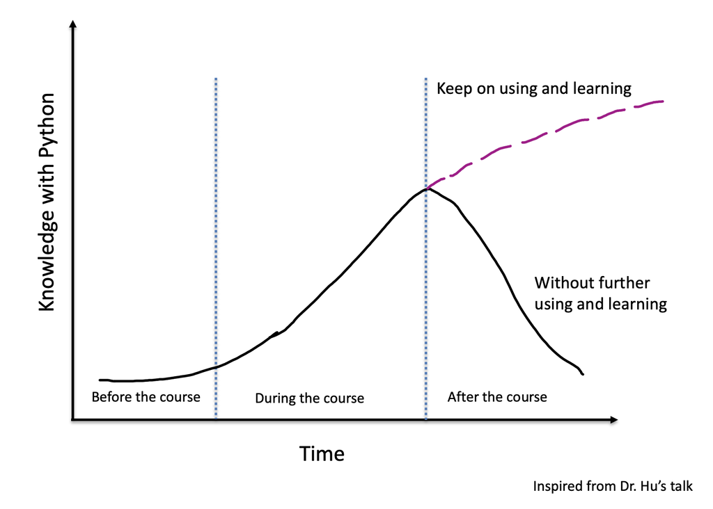

- Use it in your research
- Discuss it with your colleagues
- AI as your learning parter